# Intro To R

E

2/9/2021

### Data Frames

You can set the working directory to the folder containing your files. You can do this by `setwd("~/Eco636")` since we are working within a project, we do not need to set the working directory. Now lets load out data

```r
birds <- read.csv("birds.csv", header = TRUE)
```

We can inspect the data by calling `str()`

```r
str(birds)
```

```
## 'data.frame':    32 obs. of  10 variables:
##  $ BASIN: chr  "D" "D" "D" "D" ...
##  $ SUB  : chr  "AL" "AL" "AL" "AL" ...
##  $ BLOCK: int  1 2 3 4 5 6 7 8 9 10 ...
##  $ AMGO : int  0 NA 0 0 0 1 0 0 0 0 ...
##  $ AMRO : int  1 0 5 0 3 1 0 0 0 0 ...
##  $ BCCH : int  0 0 2 0 0 0 0 0 0 0 ...
##  $ BEKI : int  0 0 0 0 0 0 0 0 0 0 ...
##  $ BEWR : int  0 0 0 0 1 0 0 0 0 0 ...
##  $ BGWA : int  NA 0 2 2 2 2 2 2 2 2 ...
##  $ BHGR : int  25 4 1 1 1 1 1 1 1 1 ...
```

We can also request the first six records of the object by alling either `head()` or `tail()`. Below we show an example of requesting 8 lines by putting the 8 after the comma.

```r
head(birds, 8)
```

```
##   BASIN SUB BLOCK AMGO AMRO BCCH BEKI BEWR BGWA BHGR
## 1     D  AL     1    0    1    0    0    0   NA   25
## 2     D  AL     2   NA    0    0    0    0    0    4
## 3     D  AL     3    0    5    2    0    0    2    1
## 4     D  AL     4    0    0    0    0    0    2    1
## 5     D  AL     5    0    3    0    0    1    2    1
## 6     D  AL     6    1    1    0    0    0    2    1
## 7     D  AL     7    0    0    0    0    0    2    1
## 8     N  AL     8    0    0    0    0    0    2    1
```

If you wanted to see the entire data in a spreadsheet format, you can call the function `fix()`

The data includeds a column labled ‘AMRO’ which is the AMerican RObin for each sample plot (row).

```r
birds$AMRO
```

```
##  [1] 1 0 5 0 3 1 0 0 0 0 1 2 0 2 1 1 0 0 1 0 0 0 2 0 0 0 0 0 0 0 0 0
```

### R Operators

The birds data contains 32 sample plots (rows) and 10 fields (columns). The first 3 columns are plot identifiers with the first 2 being character fields (BASIN and SUB) and the third field being numeric (BLOCK). The remaining 7 fields (columns) are numeric and contain abundance for 7 different bird species.

Lets first try getting the maximum value of the 2nd species

```r
max(birds[,5])
```

```
## [1] 5
```

```r
# We can actually accomplish this another way
max(birds$AMRO)
```

```
## [1] 5
```

If we wanted to compute the total number of Americann RObins observed in all plots we would do:

```r
sum(birds[,5])
```

```
## [1] 20
```

```r
# or
sum(birds$AMRO)
```

```
## [1] 20
```

We could also look at finding how many non-zero counts AMRO were across all sites. So that would plots iwth counts greater than 0.

```r
sum(birds[,5]>0)
```

```
## [1] 11
```

To understand how we got that number, we should know that R treats TRUE values as 1 and FALSE values as 0.

```r
greaterthan0 <- birds[,5]>0
greaterthan0
```

```
##  [1]  TRUE FALSE  TRUE FALSE  TRUE  TRUE FALSE FALSE FALSE FALSE  TRUE  TRUE
## [13] FALSE  TRUE  TRUE  TRUE FALSE FALSE  TRUE FALSE FALSE FALSE  TRUE FALSE
## [25] FALSE FALSE FALSE FALSE FALSE FALSE FALSE FALSE
```

```r
# To find the total we use sum
sum(greaterthan0)
```

```
## [1] 11
```

Or we can find plots that were exactly 5 black-greaded grosbeak (BHGR)

```r
sum(birds$BHGR == 5) # Note you need to put two "="
```

```
## [1] 16
```

If we wanted to make it a bit more challenging. Lets find the max number of BHGR in sites where atleast one of the folliwng three species were observed: American Goldfinch (AMGO), American robin (AMRO) or black-capped Chickadee (BCCH). Here we will utilize the *or* operator “|”.

```r
max(birds[,"BHGR"][birds$AMGO >0 | birds$AMRO >0 | birds$BCCH > 0])
```

```
## [1] NA
```

```r
# We get an NA for the answer because the data contains NA. To ignore that we can do this:
max(birds[,"BHGR"][birds$AMGO >0 | birds$AMRO >0 | birds$BCCH >0], na.rm = T)
```

```
## [1] 25
```

### Missing Values

Missing values in R are defined by NA.

We can find NA values by either using `is.na()` or `!is.na()`. the “!” means is not.

```r
is.na(birds[,4]) # False would be is there is actually a value
```

```
##  [1] FALSE  TRUE FALSE FALSE FALSE FALSE FALSE FALSE FALSE FALSE FALSE FALSE
## [13] FALSE FALSE FALSE FALSE FALSE FALSE FALSE FALSE FALSE FALSE FALSE FALSE
## [25] FALSE FALSE FALSE FALSE FALSE FALSE FALSE FALSE
```

```r
!is.na(birds[,4]) # Now false would be is there is no value
```

```
##  [1]  TRUE FALSE  TRUE  TRUE  TRUE  TRUE  TRUE  TRUE  TRUE  TRUE  TRUE  TRUE
## [13]  TRUE  TRUE  TRUE  TRUE  TRUE  TRUE  TRUE  TRUE  TRUE  TRUE  TRUE  TRUE
## [25]  TRUE  TRUE  TRUE  TRUE  TRUE  TRUE  TRUE  TRUE
```

### Subseting Matrices or Data Frames

Lets practice with subseting data.

```r
# All rows and colums 4 through 10
birds.new <- birds[,4:10] #OR
birds.new <- birds[,-c(1:3)] # Same
birds.new
```

```
##    AMGO AMRO BCCH BEKI BEWR BGWA BHGR
## 1     0    1    0    0    0   NA   25
## 2    NA    0    0    0    0    0    4
## 3     0    5    2    0    0    2    1
## 4     0    0    0    0    0    2    1
## 5     0    3    0    0    1    2    1
## 6     1    1    0    0    0    2    1
## 7     0    0    0    0    0    2    1
## 8     0    0    0    0    0    2    1
## 9     0    0    0    0    0    2    1
## 10    0    0    0    0    0    2    1
## 11    0    1    1    0    0    2    1
## 12    0    2    0    0    0    2    1
## 13    0    0    1    0    0    0    5
## 14    0    2    0    0    1    0    5
```

[output cut: 18 more lines]

```r
# Plots where SUB is AL and all columns
birds.new <- birds[1:16,] # OR
birds.new <- birds[-c(17:32)] # Same
birds.new
```

```
##    BASIN SUB BLOCK AMGO AMRO BCCH BEKI BEWR BGWA BHGR
## 1      D  AL     1    0    1    0    0    0   NA   25
## 2      D  AL     2   NA    0    0    0    0    0    4
## 3      D  AL     3    0    5    2    0    0    2    1
## 4      D  AL     4    0    0    0    0    0    2    1
## 5      D  AL     5    0    3    0    0    1    2    1
## 6      D  AL     6    1    1    0    0    0    2    1
## 7      D  AL     7    0    0    0    0    0    2    1
## 8      N  AL     8    0    0    0    0    0    2    1
## 9      N  AL     9    0    0    0    0    0    2    1
## 10     N  AL    10    0    0    0    0    0    2    1
## 11     N  AL    11    0    1    1    0    0    2    1
## 12     N  AL    12    0    2    0    0    0    2    1
## 13     N  AL    13    0    0    1    0    0    0    5
## 14     N  AL    14    0    2    0    0    1    0    5
```

[output cut: 18 more lines]

Or we can use the `subset()` function to get the same result:

```r
# All rows and columns 4 through 10
birds.new <- subset(birds, select = AMGO:BHGR)
birds.new
```

```
##    AMGO AMRO BCCH BEKI BEWR BGWA BHGR
## 1     0    1    0    0    0   NA   25
## 2    NA    0    0    0    0    0    4
## 3     0    5    2    0    0    2    1
## 4     0    0    0    0    0    2    1
## 5     0    3    0    0    1    2    1
## 6     1    1    0    0    0    2    1
## 7     0    0    0    0    0    2    1
## 8     0    0    0    0    0    2    1
## 9     0    0    0    0    0    2    1
## 10    0    0    0    0    0    2    1
## 11    0    1    1    0    0    2    1
## 12    0    2    0    0    0    2    1
## 13    0    0    1    0    0    0    5
## 14    0    2    0    0    1    0    5
```

[output cut: 18 more lines]

```r
# Plots wehre SUB is AL and all colums
birds.new <- subset(birds, subset=SUB == 'AL')
birds.new
```

```
##    BASIN SUB BLOCK AMGO AMRO BCCH BEKI BEWR BGWA BHGR
## 1      D  AL     1    0    1    0    0    0   NA   25
## 2      D  AL     2   NA    0    0    0    0    0    4
## 3      D  AL     3    0    5    2    0    0    2    1
## 4      D  AL     4    0    0    0    0    0    2    1
## 5      D  AL     5    0    3    0    0    1    2    1
## 6      D  AL     6    1    1    0    0    0    2    1
## 7      D  AL     7    0    0    0    0    0    2    1
## 8      N  AL     8    0    0    0    0    0    2    1
## 9      N  AL     9    0    0    0    0    0    2    1
## 10     N  AL    10    0    0    0    0    0    2    1
## 11     N  AL    11    0    1    1    0    0    2    1
## 12     N  AL    12    0    2    0    0    0    2    1
## 13     N  AL    13    0    0    1    0    0    0    5
## 14     N  AL    14    0    2    0    0    1    0    5
## 15     N  AL    15    0    1    0    0    0   NA    5
## 16     N  AL    16    0    1    0    0    0   NA    5
```

### Row and Column Operations on a Matrix or Data Frame

Vector operations can be applied to every row or column of a matrix to produce a vector with the `apply()` function. (see `?apply()`).

You first supply the matrix, the direction and then the function.

Lets do this to find the maximum count of each species across the 32 plots:

```r
(bird.max <- apply(birds[,4:10],2,max)) # We use #2 for col-wise apply
```

```
## AMGO AMRO BCCH BEKI BEWR BGWA BHGR
##   NA    5    2    0    1   NA   25
```

```r
## We see the problems with the NA's again.
# Here is how we can fix it
(bird.max <- apply(birds[4:10], 2, max, na.rm = TRUE))
```

```
## AMGO AMRO BCCH BEKI BEWR BGWA BHGR
##    1    5    2    0    1    2   25
```

```r
(bird.sum <- apply(birds[,4:10], 1, sum, na.rm = TRUE)) # We use # 1 for row-wise apply
```

```
##  [1] 26  4 10  3  7  5  3  3  3  3  5  5  6  8  6  6  5  5  6  7  7  3  9  7  7
## [26]  7  1  3  3  7  5  5
```

We can use the same function `apply()` to find the sum of the number of plots where species counts are greater than 0

```r
(bird.sum <-  apply(birds[,4:10] >0, 2, sum, na.rm = TRUE))
```

```
## AMGO AMRO BCCH BEKI BEWR BGWA BHGR
##    1   11    3    0    2   20   32
```

We can use the apply function to call other functions

```r
apply(X = birds[,4:10], MARGIN = 2, FUN = sum)
```

```
## AMGO AMRO BCCH BEKI BEWR BGWA BHGR
##   NA   20    4    0    2   NA  123
```

```r
# OR
apply(birds[,4:10],2,sum)
```

```
## AMGO AMRO BCCH BEKI BEWR BGWA BHGR
##   NA   20    4    0    2   NA  123
```

```r
# The two are the same
```

### Importing and Exporting Data

After importing your data in, you can examine it.

One thing you might want to do is look at the `row.names()` and `colnames()`.

```r
# Look at the names
row.names(birds)
```

```
##  [1] "1"  "2"  "3"  "4"  "5"  "6"  "7"  "8"  "9"  "10" "11" "12" "13" "14" "15"
## [16] "16" "17" "18" "19" "20" "21" "22" "23" "24" "25" "26" "27" "28" "29" "30"
## [31] "31" "32"
```

```r
colnames(birds)
```

```
##  [1] "BASIN" "SUB"   "BLOCK" "AMGO"  "AMRO"  "BCCH"  "BEKI"  "BEWR"  "BGWA"
## [10] "BHGR"
```

Lets convert the BLOCK field from an integer (numeric) to a factor (categorical)

```r
birds$BLOCK <- as.factor(birds$BLOCK)
```

To check that it did what we wanted, lets view the structure of the data

```r
str(birds)
```

```
## 'data.frame':    32 obs. of  10 variables:
##  $ BASIN: chr  "D" "D" "D" "D" ...
##  $ SUB  : chr  "AL" "AL" "AL" "AL" ...
##  $ BLOCK: Factor w/ 16 levels "1","2","3","4",..: 1 2 3 4 5 6 7 8 9 10 ...
##  $ AMGO : int  0 NA 0 0 0 1 0 0 0 0 ...
##  $ AMRO : int  1 0 5 0 3 1 0 0 0 0 ...
##  $ BCCH : int  0 0 2 0 0 0 0 0 0 0 ...
##  $ BEKI : int  0 0 0 0 0 0 0 0 0 0 ...
##  $ BEWR : int  0 0 0 0 1 0 0 0 0 0 ...
##  $ BGWA : int  NA 0 2 2 2 2 2 2 2 2 ...
##  $ BHGR : int  25 4 1 1 1 1 1 1 1 1 ...
```

Now we can see that BLOCK is a factor with 16 levels. Alternatively, we can ask for the class of BLOCK

```r
class(birds$BLOCK)
```

```
## [1] "factor"
```

There are many ways to get data out of R. Here we will work on outputting a data frame using `write.table()`.

Lets take the birds data set and store it as an object named *birds* as a comma-delinited file:

```r
write.table(birds, 'myNewFile.csv', row.names = FALSE, sep = ',')
```

this will save the object birds to a file names *myNewFile.csv* in the current working directory.

A few things to watch out for using `write.table()` is that it will overwrite a file by the same name if it exists in the output directory. However if you wish to append the object to the existing file, you can add the `append = TRUE` argument to the statement which will append the new file to the bottom of the existing one. To familiarize yourself with this funciton, look at `?write.table`.

### Plotting in R

R can produce a broad range of graphic devices. This includes postscript, pdf, xfig, pgn jepg and more. To learn about what devices R has, try `?Devices`

```r
x <- sort(runif(25, -2,2))
y <- rnorm(25, 20 + 4.5*x, 2)
```

Now we can produce a simple scatter plot

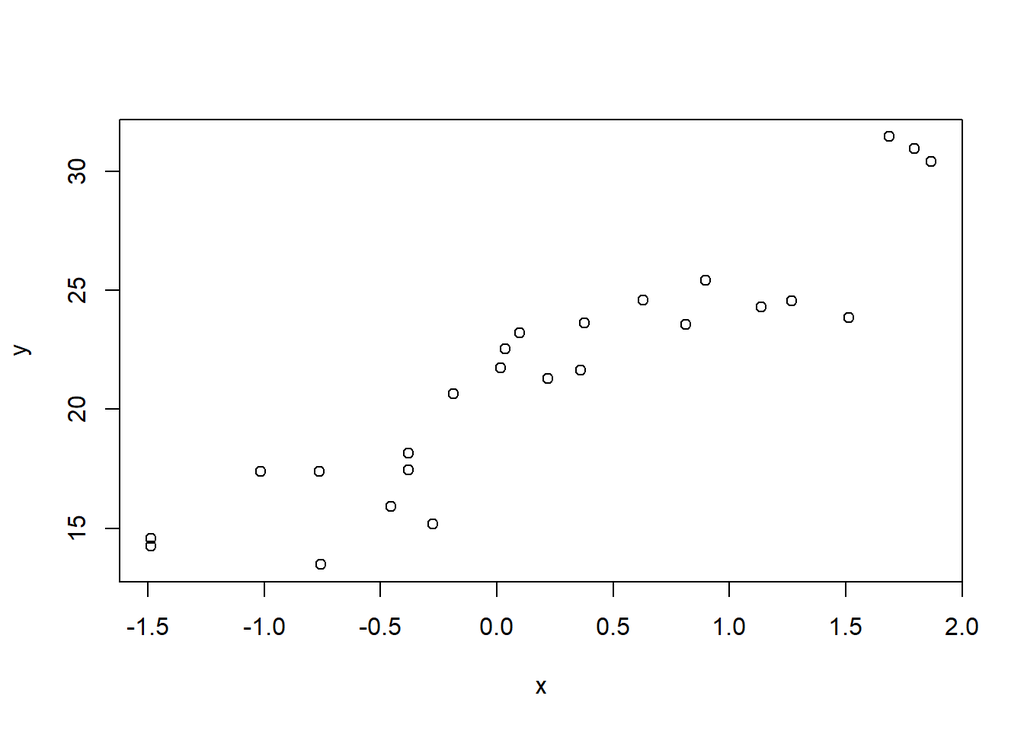

```r
plot(x,y)
```

We can change the type of plot we want to use:

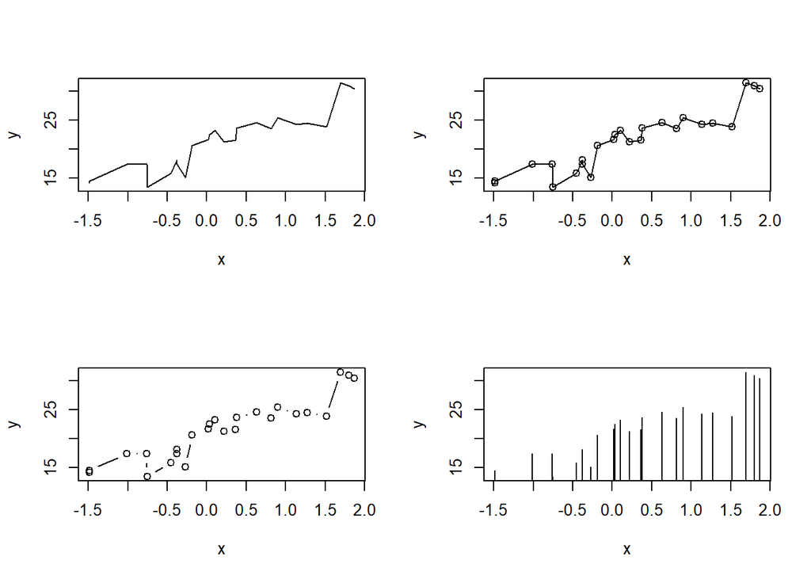

```r
par(mfrow = c(2,2))
plot(x,y, type = 'l')
plot(x,y, type = 'o')
plot(x,y, type = 'b')
plot(x,y, type = 'h')
```

We can also change the *line type*:

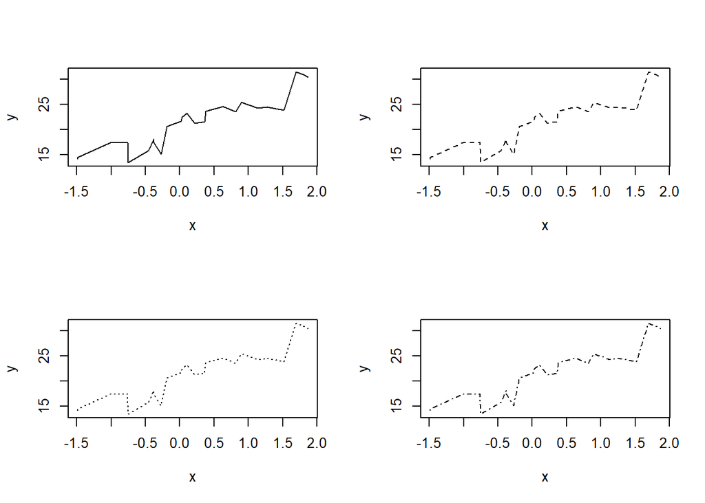

```r
par(mfrow=c(2,2))
plot(x,y, type = 'l', lty = 1)
plot(x,y, type = 'l', lty = 2)
plot(x,y, type = 'l', lty = 3)
plot(x,y, type = 'l', lty = 4)
```

Or you can do *line width*

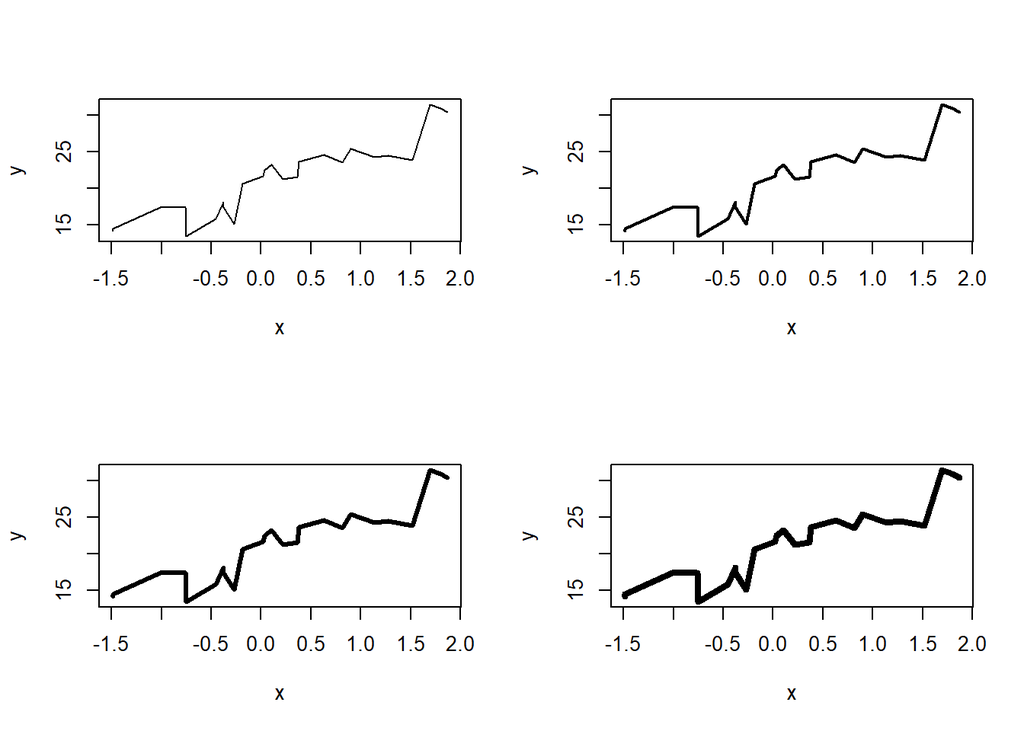

```r
par(mfrow=c(2,2))
plot(x,y,type='l', lty=1,lwd=1)
plot(x,y,type='l', lty=1,lwd=2)
plot(x,y,type='l', lty=1,lwd=3)
plot(x,y,type='l', lty=1,lwd=4)
```

or you can change the *symbol* we want to use

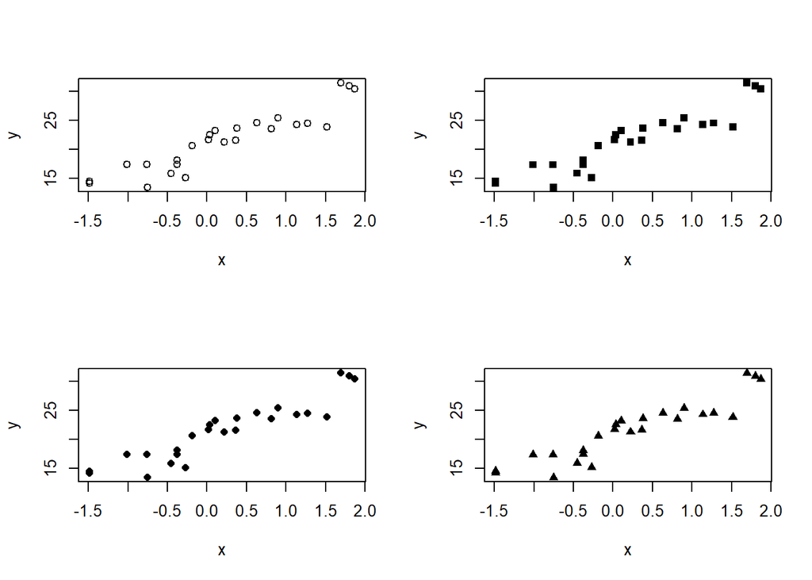

```r
par(mfrow=c(2,2))
plot(x,y,type='p', pch=1)
plot(x,y,type='p', pch=15)
plot(x,y,type='p', pch=16)
plot(x,y,type='p', pch=17)
```

Even the size of the symbol

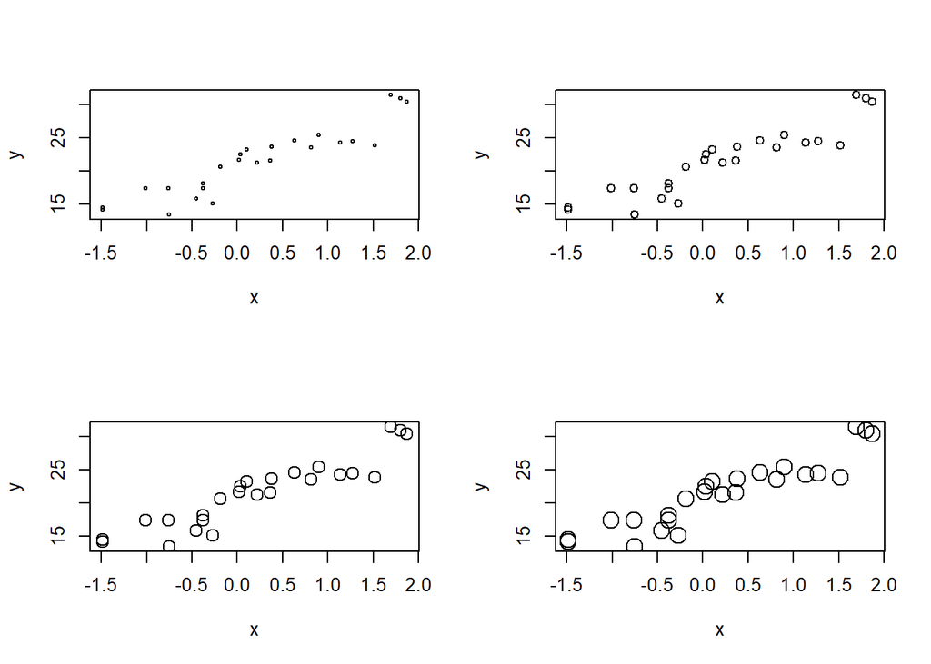

```r
par(mfrow=c(2,2))
plot(x,y,type='p', pch=1, cex=0.5)
plot(x,y,type='p', pch=1, cex=1)
plot(x,y,type='p', pch=1, cex=1.5)
plot(x,y,type='p', pch=1, cex=2)
```

Now even the color

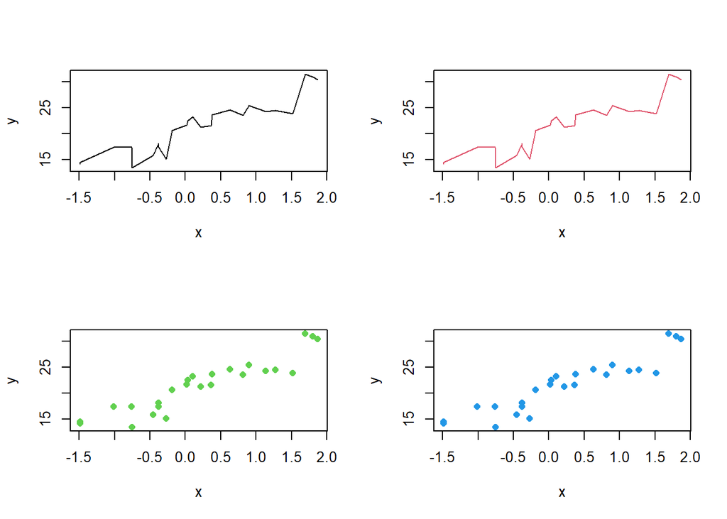

```r
par(mfrow=c(2,2))
plot(x,y,type='l', col=1)
plot(x,y,type='l', col=2)
plot(x,y,type='p', pch=16, col=3)
plot(x,y,type='p', pch=16, col=4)
```

Most or all of the par commands control the graphics to plot. You need to pass the `par()` function before plotting anything. Useful examples are:

```r
# partition the plotting reagion into 2 rows and 3 columns.
par(mfrow=c(2,3))
# used to overlay different plot types
par(new=TRUE)
# specifies margin size in inches (bottom, left, top, right) etc.
par(mai=c(0.6,0.5,0.1,0.5))
# all of the above in a single command
par(mfrow=c(2,3), new=TRUE, mai=c(0.6,0.5,0.1,0.5))
```